# Multi Factor ANOVA Problem Set

Your Name Here

# 1 Introduction

This problem set corresponds to the section on multi factor ANOVA in the course https://doe.dscoe.org.

For this problem set, we will use the following packages:

```r
library(tidyverse)
library(ggpubr) # Note, we haven't used it yet in the course, but its a convenient package for combining multiple plots
```

# 2 Simulation

You are an analyst working on a top secret program and are given the file multi_factor.csv to analyze.[^1] The data shows the results for a simulation where four factors, A, B, C, and D are measured at a “low” (represented as -1) and “high” (represented as 1) level and their response is as indicated. There was only one replicate for each treatment combination[^2]

## 2.1 Input the Data

Read the data and clean it as necessary.

```r
# Read the data using read.csv
sim <- read.csv('./multi_factor.csv')
# Each of the levels of A, B, C, and D are read as integers, but they really need to be
# understood as factors named "-1" and "1"
sim$A <- as.factor(sim$A)
sim$B <- as.factor(sim$B)
sim$C <- as.factor(sim$C)
sim$D <- as.factor(sim$D)

head(sim)
```

```
##   Response  A  B  C  D
## 1     1.92 -1 -1 -1 -1
## 2    11.28  1 -1 -1 -1
## 3     1.09 -1  1 -1 -1
## 4     5.75  1  1 -1 -1
## 5     2.13 -1 -1  1 -1
## 6     9.53  1 -1  1 -1
```

## 2.2 Visualize the Data

Plot the data in a way that allows you to understand something about the effects (main or interaction) of the factors. Interpret your results.

Note - we are dealing with five dimensional data (the Response and factors A, B, C, and D); there will be many ways to view this.

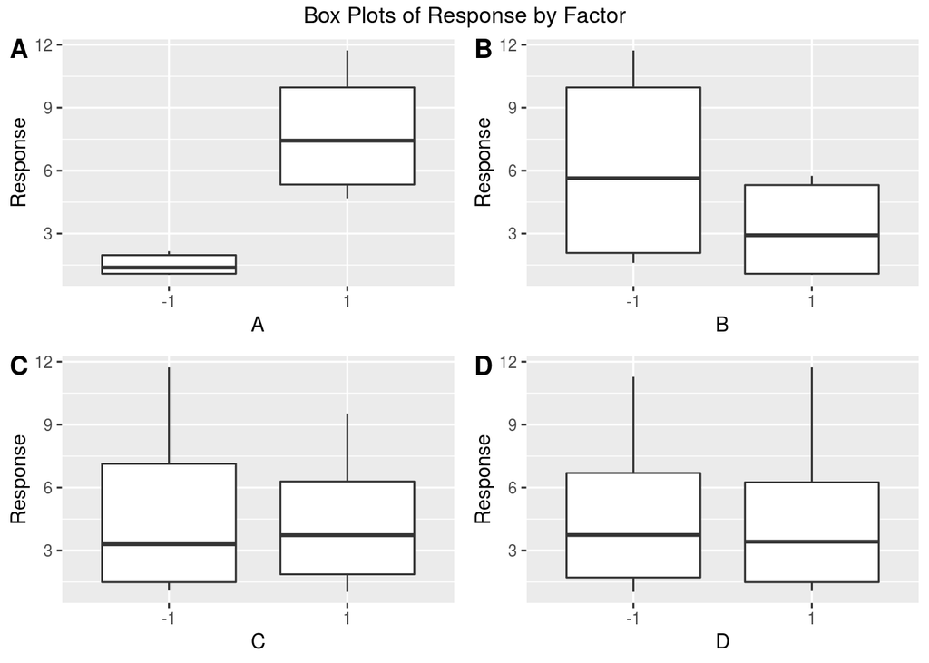

```r
# There are many ways to do this!
# Visualizing 5-D data is hard!
# Here are some options:

# Box plots
# Note as we only have one replicate per treatment combination, we can really only view main effects:

# Make a boxplot for each of the Factors
Plot.A <- ggplot(sim) + geom_boxplot(aes(x = A, y = Response))
Plot.B <- ggplot(sim) + geom_boxplot(aes(x = B, y = Response))
Plot.C <- ggplot(sim) + geom_boxplot(aes(x = C, y = Response))
Plot.D <- ggplot(sim) + geom_boxplot(aes(x = D, y = Response))

# ggarrange (in ggpubr) allows you to combine multiple, disparate plots
# you simply list them as desired
ggarrange(Plot.A, Plot.B, Plot.C, Plot.D,
          # You can choose the number of columns and rows
          ncol = 2, nrow = 2,
          # You can label the plots as desired (or title them when you make them)
          labels = c('A', 'B', 'C', 'D')) %>%
  # You can use piping to pass the plot to other ggpubr functions, e.g. annotate_figure
  # This provides a title for the entire plot
  annotate_figure(top = 'Box Plots of Response by Factor')
```

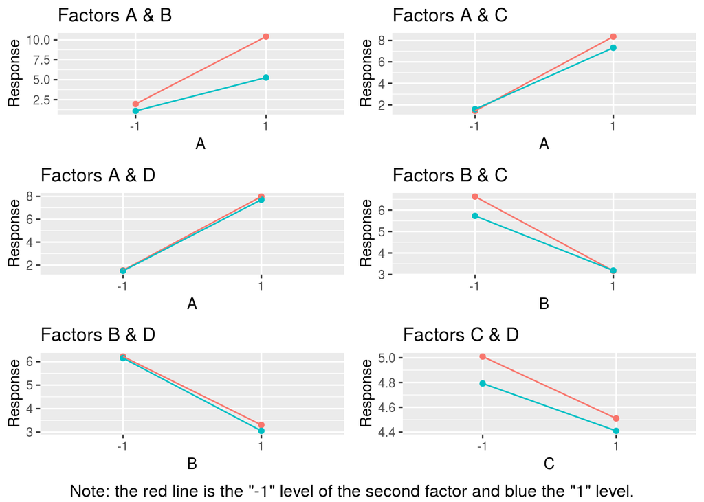

```r
# You'll see something useful here:
# 1) Note that within each boxplot, there are 8 x points, each from the variosu treatment combinations
#   that include the x axis factor at the indicated level
# 2) We can get an idea of which factors likely have an effect
#    For example, A almost assuredly has an effect; B might; C and D likely do not


# Trace Plots
# These are somewhat hard to do with many dimensions
# We can really only view 2-way interactions
# so we have to look at all the combinations
# Here we plot each set of choosing 2 factors out of A, B, C, and D
# We could also opt to look at the inverse version of these plots, but that is
# left as an exercise to the reader

# Produce trace plots, note that each group will have 4 x replicates from which to gather a mean
Plot.AB <- ggplot(sim, aes(x = A, y = Response, color = B, group = B)) +
  stat_summary(fun = 'mean', geom = 'point') +
  stat_summary(fun = 'mean', geom = 'line') +
  ggtitle('Factors A & B')

Plot.AC <- ggplot(sim, aes(x = A, y = Response, color = C, group = C)) +
  stat_summary(fun = 'mean', geom = 'point') +
  stat_summary(fun = 'mean', geom = 'line') +
  ggtitle('Factors A & C')

Plot.AD <- ggplot(sim, aes(x = A, y = Response, color = D, group = D)) +
  stat_summary(fun = 'mean', geom = 'point') +
  stat_summary(fun = 'mean', geom = 'line') +
  ggtitle('Factors A & D')

Plot.BC <- ggplot(sim, aes(x = B, y = Response, color = C, group = C)) +
  stat_summary(fun = 'mean', geom = 'point') +
  stat_summary(fun = 'mean', geom = 'line') +
  ggtitle('Factors B & C')

Plot.BD <- ggplot(sim, aes(x = B, y = Response, color = D, group = D)) +
  stat_summary(fun = 'mean', geom = 'point') +
  stat_summary(fun = 'mean', geom = 'line') +
  ggtitle('Factors B & D')

Plot.CD <- ggplot(sim, aes(x = C, y = Response, color = D, group = D)) +
  stat_summary(fun = 'mean', geom = 'point') +
  stat_summary(fun = 'mean', geom = 'line') +
  ggtitle('Factors C & D')

# Arrange the plots into a 3x2 grid
ggarrange(Plot.AB, Plot.AC, Plot.AD, Plot.BC, Plot.BD, Plot.CD,
          ncol = 2, nrow = 3,
          # Removed the legends as they take up much space
          legend = 'none') %>%
  # Annotate what red and blue mean
  annotate_figure(bottom = 'Note: the red line is the "-1" level of the second factor and blue the "1" level.')
```

```r
# We can use this to visualize something about the two way interactions and th effects of the factors
# Note that if the two lines are on top of each other (for example the A &D plot) it indicates the
# second factor has almost no impact
# Note that if the lines are approximately horizontal, it shows the first factor has almost no impact
# We don't see that here, but if you used D as an x axis, you would likely see that
# Finally, note that if the lines cross, it indicates a significant interaction between the two factors
# We don't see that too significantly, but you do see it to some extent with A & B, as the distance between the lines
# closes for the two levels of A.
```

## 2.3 Conduct ANOVA

Conduct an four ANOVAs on this data:

- One where you only consider the main effects.
- One where you consider the main effects and all two-way interactions.
- One where you consider the above plus all three-way interactions.
- One where you consider the above plus the four-way interaction.

For each ANOVA, identify the factors you would consider significant. Use $\alpha = .05$ for your analysis.

```r
# Main effects
summary(aov(Response ~ . , data = sim))
```

```
##             Df Sum Sq Mean Sq F value   Pr(>F)
## A            1 159.83  159.83  75.863 2.88e-06 ***
## B            1  36.09   36.09  17.130  0.00165 **
## C            1   0.78    0.78   0.370  0.55554
## D            1   0.10    0.10   0.048  0.83086
## Residuals   11  23.18    2.11
## ---
## Signif. codes:  0 '***' 0.001 '**' 0.01 '*' 0.05 '.' 0.1 ' ' 1
```

```r
# If we just consider main effects, we can say factors A and B are statistically significant.

# Main Effects + 2nd Order
summary(aov(Response ~ . + .:., data = sim))
```

```
##             Df Sum Sq Mean Sq F value   Pr(>F)
## A            1 159.83  159.83 317.882 1.02e-05 ***
## B            1  36.09   36.09  71.777 0.000376 ***
## C            1   0.78    0.78   1.549 0.268450
## D            1   0.10    0.10   0.200 0.673061
## A:B          1  18.30   18.30  36.390 0.001802 **
## A:C          1   1.42    1.42   2.828 0.153447
## A:D          1   0.05    0.05   0.103 0.761312
## B:C          1   0.84    0.84   1.674 0.252236
## B:D          1   0.04    0.04   0.070 0.802007
## C:D          1   0.01    0.01   0.027 0.874880
## Residuals    5   2.51    0.50
## ---
## Signif. codes:  0 '***' 0.001 '**' 0.01 '*' 0.05 '.' 0.1 ' ' 1
```

```r
# If we include 2nd order interactions, we say factors A and B are statistically significant
# Also, the AB interaction is significant

# Main Effects + 2nd order + 3rd order
summary(aov(Response ~ . + .:. + .:.:. , data = sim))
```

```
##             Df Sum Sq Mean Sq F value Pr(>F)
## A            1 159.83  159.83 496.288 0.0286 *
## B            1  36.09   36.09 112.061 0.0600 .
## C            1   0.78    0.78   2.418 0.3638
## D            1   0.10    0.10   0.313 0.6753
## A:B          1  18.30   18.30  56.813 0.0840 .
## A:C          1   1.42    1.42   4.416 0.2828
## A:D          1   0.05    0.05   0.161 0.7573
## B:C          1   0.84    0.84   2.614 0.3526
## B:D          1   0.04    0.04   0.109 0.7969
## C:D          1   0.01    0.01   0.043 0.8700
## A:B:C        1   1.90    1.90   5.892 0.2488
## A:B:D        1   0.15    0.15   0.466 0.6186
## A:C:D        1   0.00    0.00   0.006 0.9524
## B:C:D        1   0.14    0.14   0.442 0.6263
## Residuals    1   0.32    0.32
## ---
## Signif. codes:  0 '***' 0.001 '**' 0.01 '*' 0.05 '.' 0.1 ' ' 1
```

```r
# If we include 3rd order interactions, we only can claim that factor A is statistically significant

# Main Effects + 2nd order + 3rd order + 4th order
summary(aov(Response ~ . + .:. + .:.:. + .:.:.:., data = sim))
```

```
##             Df Sum Sq Mean Sq
## A            1 159.83  159.83
## B            1  36.09   36.09
## C            1   0.78    0.78
## D            1   0.10    0.10
## A:B          1  18.30   18.30
## A:C          1   1.42    1.42
## A:D          1   0.05    0.05
## B:C          1   0.84    0.84
## B:D          1   0.04    0.04
## C:D          1   0.01    0.01
## A:B:C        1   1.90    1.90
## A:B:D        1   0.15    0.15
## A:C:D        1   0.00    0.00
## B:C:D        1   0.14    0.14
## A:B:C:D      1   0.32    0.32
```

```r
# If we attempt to include 4th order interactions we run into a problem:
# We do not have enough degrees of freedom to estimate the residuals and therefore
# We cannot get an F value and a corresponding p-value
# We simply cannot do this analysis at this level of fidelity!
```

What did you notice about:

- The p-values for the factors you initially considered significant.
- The degrees of freedom available for the residuals.

```
The p-values generally went up for the factors we noted as significant.
We had fewer and fewer degrees of freedom available for the resiudals (i.e. the epsilon term).
Eventually there were no degrees of freedom for the fourth order effect and we could not actually
calculate any p-values
```

Why might there be a change? (No need to explain this mathematically precisely, just conceptually).

```
We became increasingly less certain if variation was caused by any one factor as
we increased the number of explanatory variables in our model (i.e., factors).
This meant we had less degrees of freedom by which to model the residuals.

As ANOVA relies on comparing the variance within groups to the variance of an entire sample, as
the size of the groups shrank, we were less certain about the distinction between the variances,
until ultimately when the groups were of size 1, we could not assess the variance and therefore
note assess the F stat and p-value

More generally, if we try to do ANOVA to the fourth order,
we have perfectly explained our model, i.e. there is no error to assess and thus
our error is not normally distributed, etc.  This is called overfitting
```

## 2.4 Pick a Model

Choose one model, explain why you chose this, and check its assumptions.

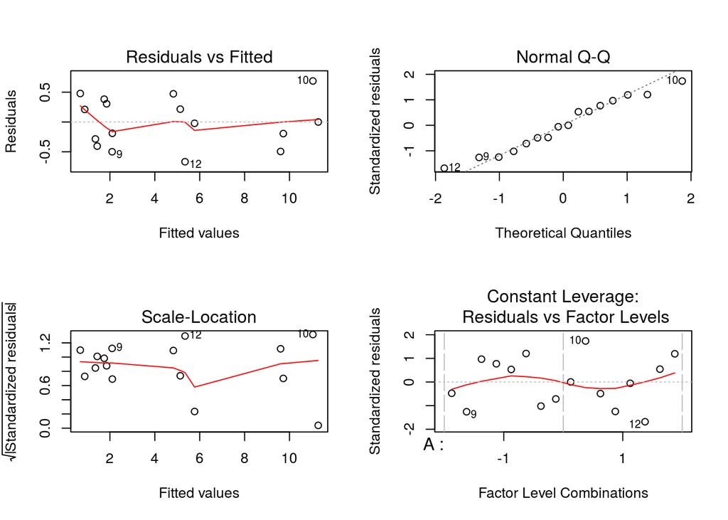

```r
# I chose the 2nd order model as it allows for a number of DF on the error
# and corresponds to what we see visually with the data

sim.aov.2 <- aov(Response ~ . + .:., data = sim)
par(mfrow = c(2,2))
plot(sim.aov.2)
```

```r
#Nothing in the plots indicates that we have failed assumptions, but we can check numerically

# Normality
shapiro.test(sim.aov.2$residuals)
```

```
##
##  Shapiro-Wilk normality test
##
## data:  sim.aov.2$residuals
## W = 0.96058, p-value = 0.6723
```

```r
# We fail to reject that the residuals are normally distributed

# Homoskedasticity
bartlett.test(sim.aov.2$residuals, sim$A)
```

```
##
##  Bartlett test of homogeneity of variances
##
## data:  sim.aov.2$residuals and sim$A
## Bartlett's K-squared = 0.19258, df = 1, p-value = 0.6608
```

```r
bartlett.test(sim.aov.2$residuals, sim$B)
```

```
##
##  Bartlett test of homogeneity of variances
##
## data:  sim.aov.2$residuals and sim$B
## Bartlett's K-squared = 0.0024057, df = 1, p-value = 0.9609
```

```r
bartlett.test(sim.aov.2$residuals, sim$C)
```

```
##
##  Bartlett test of homogeneity of variances
##
## data:  sim.aov.2$residuals and sim$C
## Bartlett's K-squared = 0.20308, df = 1, p-value = 0.6522
```

```r
bartlett.test(sim.aov.2$residuals, sim$D)
```

```
##
##  Bartlett test of homogeneity of variances
##
## data:  sim.aov.2$residuals and sim$D
## Bartlett's K-squared = 3.1947, df = 1, p-value = 0.07388
```

```r
# we fail to reject that the residuals do not have constant variance against the factors
```

[^1]: The reality is, this was data from an industrial application of silicon wafers, but who cares about that?
[^2]: We have not yet introduced this term, but this is the combination of the levels of each factor for an experiment / simulation run. For example, Factor A, Factor B, Factor C, Factor D all set to “-1” is one treatment combination.